# GeneAnnotation

# Alluvial flow digram frgament flows

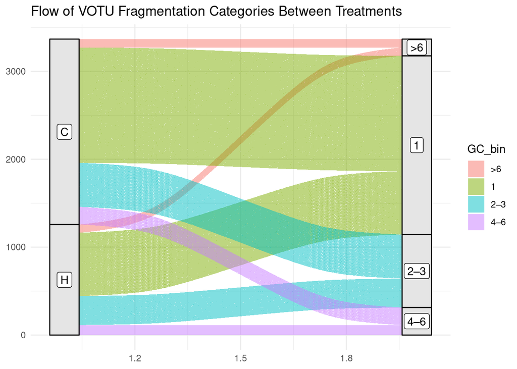

```r
library(ggalluvial)

alluvial_df <- votu_taxonomy2 |>
  mutate(
    GC_bin = case_when(
      GenomeCount <= 1 ~ "1",
      GenomeCount <= 3 ~ "2–3",
      GenomeCount <= 6 ~ "4–6",
      TRUE ~ ">6"
    )
  )

ggplot(alluvial_df,
       aes(axis1 = Treatment, axis2 = GC_bin)) +
  geom_alluvium(aes(fill = GC_bin), width = 1/12) +
  geom_stratum(width = 1/12, fill = "grey90") +
  geom_label(stat = "stratum", aes(label = after_stat(stratum))) +
  theme_minimal() +
  labs(title = "Flow of VOTU Fragmentation Categories Between Treatments")
```

Thicker bands.. more VOTUs. Control has more VOTUS overall (2000ish) You can see wider ribbons flow into bins from control that have more fragments

# cleaner version of flow

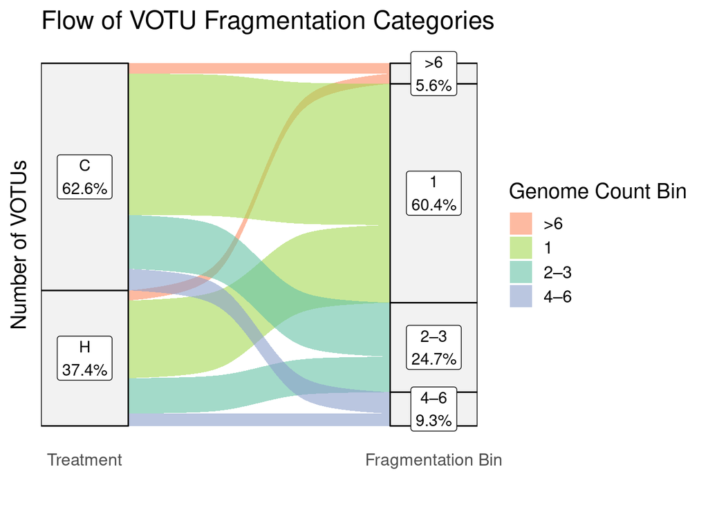

```r
flow_df <- alluvial_df |>
  dplyr::count(Treatment, GC_bin, name = "Freq")

ggplot2::ggplot(
  flow_df,
  ggplot2::aes(axis1 = Treatment, axis2 = GC_bin, y = Freq)
) +

  ggalluvial::geom_alluvium(
    ggplot2::aes(fill = GC_bin),
    width = 0.25, alpha = 0.6, knot.pos = 0.4
  ) +

  ggalluvial::geom_stratum(
    width = 0.25, fill = "grey95", color = "black"
  ) +

  ggplot2::geom_label(
    stat = "stratum",
    ggplot2::aes(
      label = paste0(
        after_stat(stratum),
        "\n",
        round(after_stat(prop) * 100, 1), "%"
      )
    ),
    fill = "white", size = 4
  ) +

  ggplot2::scale_x_discrete(
    limits = c("Treatment", "Fragmentation Bin"),
    expand = c(.05, .05)
  ) +

  ggplot2::scale_fill_manual(values = c(
    "1" = "#A6D854",
    "2–3" = "#66C2A5",
    "4–6" = "#8DA0CB",
    ">6" = "#FC8D62"
  )) +

  ggplot2::labs(
    title = "Flow of VOTU Fragmentation Categories",
    y = "Number of VOTUs",
    x = "",
    fill = "Genome Count Bin"
  ) +

  ggplot2::theme_minimal(base_size = 15) +
  ggplot2::theme(
    axis.text.y = ggplot2::element_blank(),
    panel.grid = ggplot2::element_blank()
  )
```

Limitation of the package is ribbons cant be labeled directly, only stratum labels

# Which phyla controbute msot to heated only vs control only VOTUS

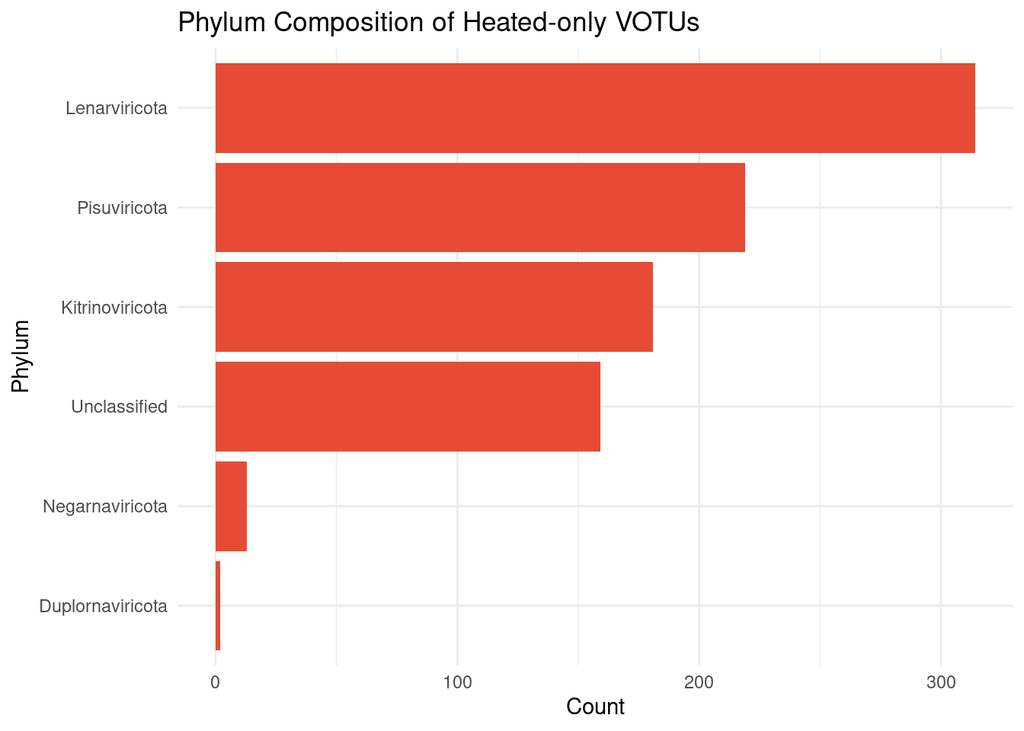

```r
# create heated-only, control-only, shared
votu_status <- votu_matrix |>
  dplyr::mutate(
    Status = dplyr::case_when(
      C > 0 & H > 0  ~ "Shared",
      C > 0 & H == 0 ~ "Control-only",
      H > 0 & C == 0 ~ "Heated-only"
    )
  )

# bring taxonomy
votu_status_tax <- votu_status |>
  dplyr::left_join(votu_taxonomy2, by = "VOTU")

# plot phylum composition for heated-only VOTUs
heated_only_phylum <- votu_status_tax |>
  dplyr::filter(Status == "Heated-only") |>
  dplyr::count(Phylum)

ggplot2::ggplot(
  heated_only_phylum,
  ggplot2::aes(x = stats::reorder(Phylum, n), y = n)
) +
  ggplot2::geom_col(fill = "#E64B35") +
  ggplot2::coord_flip() +
  ggplot2::theme_minimal() +
  ggplot2::labs(
    title = "Phylum Composition of Heated-only VOTUs",
    x = "Phylum",
    y = "Count"
  )
```

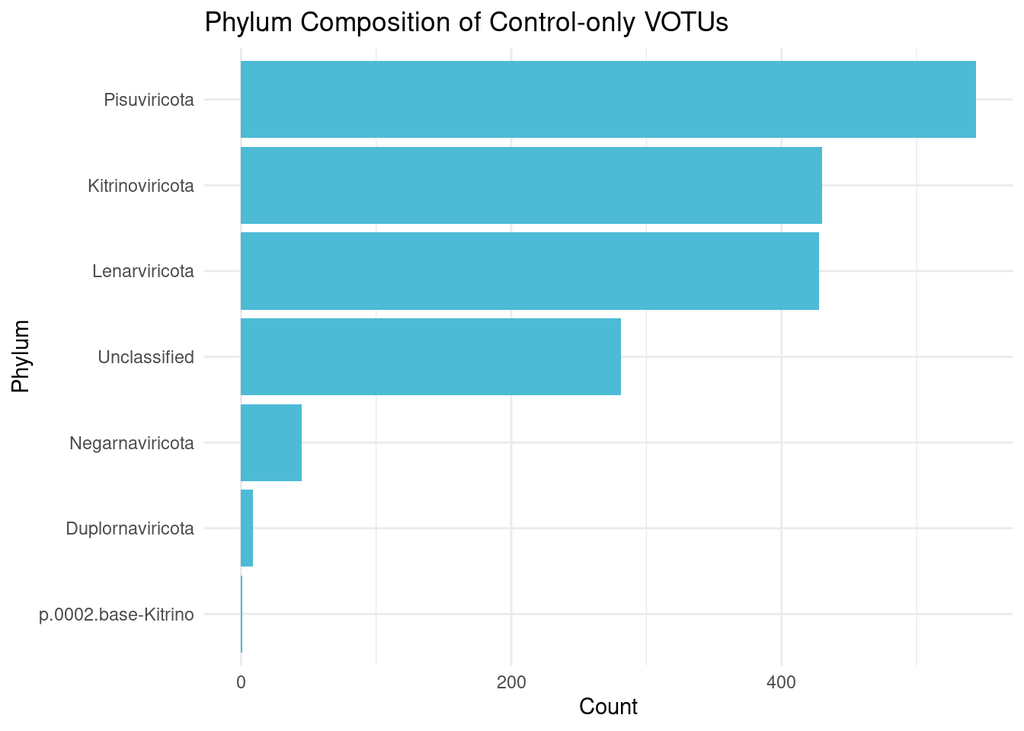

```r
# control-only phylum composition
control_only_phylum <- votu_status_tax |>
  dplyr::filter(Status == "Control-only") |>
  dplyr::count(Phylum)

ggplot2::ggplot(
  control_only_phylum,
  ggplot2::aes(x = stats::reorder(Phylum, n), y = n)
) +
  ggplot2::geom_col(fill = "#4DBBD5") +
  ggplot2::coord_flip() +
  ggplot2::theme_minimal() +
  ggplot2::labs(
    title = "Phylum Composition of Control-only VOTUs",
    x = "Phylum",
    y = "Count"
  )
```

# Building one clean table to use

```r
viral <- read_tsv(
  "/work/pi_jlb_umass_edu/blanchardlab/RNA_phages//RVMT_Zenodo_V4/Expanded_Contig_Set/viral_contigs_annotated_full.tsv",
  show_col_types = FALSE
)

viral_with_votu <- viral %>%
  mutate(VOTU = paste0(RCR90, "__", RvANI90)) %>%
  select(Contig, ND, VOTU, Phylum, Class, Order, Family, Genus, Novel)


rdrp_clean <- rdrp_contigs %>%
  select(
    Contig,
    ND = ND.x,
    Full_name = Full_name,
    Treatment, Site, Subplot, Layer,
    Order = Order.x,
    Family = Family.x,
    Genus = Genus.x,
    Phylum = Phylum.x,
    Novel = Novel.x,
    Segmented = Segmented.x,
    Length = Length.x,
    Host = Host.x,
    Host_Evidence = Host_Evidence.x
  ) %>%
  distinct()

colnames(votu_rdrp)
```

```
 [1] "Full_name"     "RID"           "ND"            "Treatment"
 [5] "Site"          "Subplot"       "Layer"         "Order"
 [9] "Family"        "Genus"         "Phylum"        "Novel"
[13] "Segmented"     "Length"        "Host"          "Host_Evidence"
[17] "Contig"        "Contig length" "VOTU"
```

# Counts per Phylum per VOTU (not proportional)

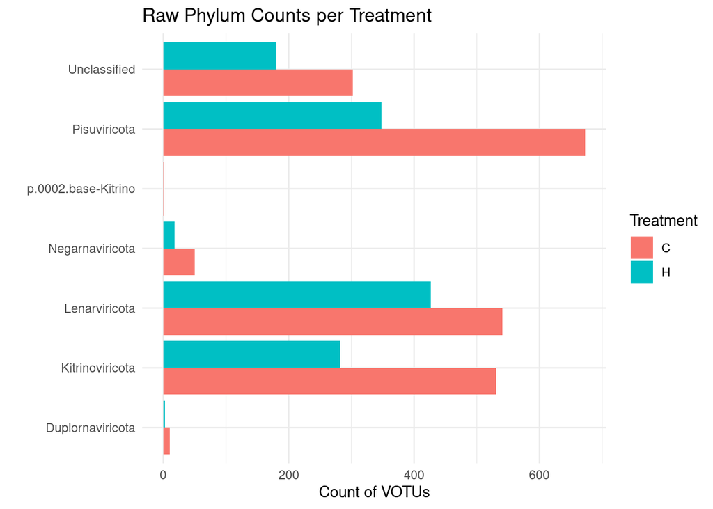

```r
phylum_counts <- votu_taxonomy2 |>
  dplyr::count(Phylum, Treatment)

ggplot2::ggplot(
  phylum_counts,
  ggplot2::aes(x = Phylum, y = n, fill = Treatment)
) +
  ggplot2::geom_col(position = "dodge") +
  ggplot2::coord_flip() +
  ggplot2::theme_minimal() +
  ggplot2::labs(
    title = "Raw Phylum Counts per Treatment",
    y = "Count of VOTUs",
    x = ""
  )
```

# Histogram count of genome bins

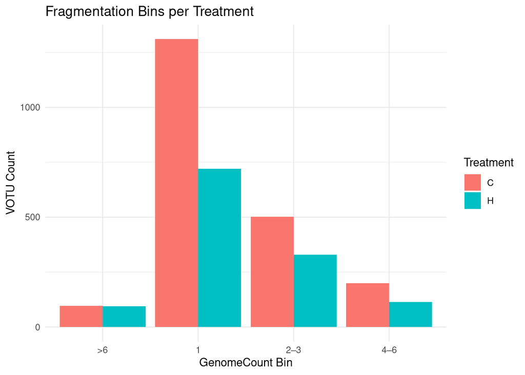

```r
votu_taxonomy2 <- votu_taxonomy2 |>
  mutate(
    GC_bin = case_when(
      GenomeCount == 1 ~ "1",
      GenomeCount <= 3 ~ "2–3",
      GenomeCount <= 6 ~ "4–6",
      TRUE ~ ">6"
    )
  )

ggplot(votu_taxonomy2,
       aes(x = GC_bin, fill = Treatment)) +
  geom_bar(position = "dodge") +
  theme_minimal() +
  labs(
    title = "Fragmentation Bins per Treatment",
    y = "VOTU Count",
    x = "GenomeCount Bin"
  )
```

```r
saveRDS(votu_taxonomy2, "votu_taxonomy2.rds")
```

# Fischer exact for fragmentation

```r
tbl <- table(votu_taxonomy2$Treatment, votu_taxonomy2$GC_bin)
fisher.test(tbl)
```

```
    Fisher's Exact Test for Count Data

data:  tbl
p-value = 0.0008248
alternative hypothesis: two.sided
```

# Fischer exact for Hv C tail (higher fragmentaiton difference?)

```r
tbl_tail <- table(
  votu_taxonomy2$Treatment,
  votu_taxonomy2$GenomeCount > 5
)
fisher.test(tbl_tail)
```

```
    Fisher's Exact Test for Count Data

data:  tbl_tail
p-value = 0.002207
alternative hypothesis: true odds ratio is not equal to 1
95 percent confidence interval:
 1.152719 1.944580
sample estimates:
odds ratio
  1.497941
```

# 4. Same ND, same VOTU, multiple contigs.. tells how many sample metatrancirptome have the same VOTU assembled into more than one contig.

```r
reassembly_candidates <- votu_rdrp |>
  dplyr::group_by(ND, VOTU) |>
  dplyr::summarize(n_contigs = dplyr::n_distinct(Contig), .groups = "drop") |>
  dplyr::filter(n_contigs > 1)

head(reassembly_candidates)
```

```
# A tibble: 6 × 3
  ND        VOTU                      n_contigs
  <chr>     <chr>                         <int>
1 ND_173519 Rv4_178079__ANI90_0003966         2
2 ND_173521 Rv4_183811__ANI90_0007119         2
3 ND_173528 Rv4_179243__ANI90_0007567         3
4 ND_173531 Rv4_180692__ANI90_0063356         2
5 ND_173719 Rv4_006932__ANI90_0006451         2
6 ND_173922 Rv4_176947__ANI90_0006911         2
```

```r
# per-ND per-VOTU contig counts
reassembly_candidates <- votu_rdrp |>
  dplyr::group_by(ND, VOTU) |>
  dplyr::summarize(n_contigs = dplyr::n_distinct(Contig), .groups = "drop") |>
  dplyr::filter(n_contigs > 1)

# 1. ND–VOTU combinations with >1 contig
total_pairs <- nrow(reassembly_candidates)

# 2. unique NDs showing this behavior
total_NDs <- reassembly_candidates |>
  dplyr::distinct(ND) |>
  nrow()

# 3. unique VOTUs showing this behavior
total_VOTUs <- reassembly_candidates |>
  dplyr::distinct(VOTU) |>
  nrow()

# 4. split by treatment
by_treatment <- votu_rdrp |>
  dplyr::group_by(ND, VOTU, Treatment) |>
  dplyr::summarize(n_contigs = dplyr::n_distinct(Contig), .groups = "drop") |>
  dplyr::filter(n_contigs > 1) |>
  dplyr::count(Treatment)

list(
  ND_VOTU_pairs_with_multiple_contigs = total_pairs,
  unique_NDs_with_fragmentation = total_NDs,
  unique_VOTUs_with_fragmentation = total_VOTUs,
  treatment_breakdown = by_treatment
)
```

```
$ND_VOTU_pairs_with_multiple_contigs
[1] 156

$unique_NDs_with_fragmentation
[1] 156

$unique_VOTUs_with_fragmentation
[1] 138

$treatment_breakdown
# A tibble: 2 × 2
  Treatment     n
  <chr>     <int>
1 C            76
2 H            80
```

```r
# total number of ND samples per treatment
total_NDs_by_treat <- votu_rdrp |>
  dplyr::distinct(ND, Treatment) |>
  dplyr::count(Treatment, name = "total_NDs")

# NDs that have multi-contig VOTUs
NDs_with_multicontig <- votu_rdrp |>
  dplyr::group_by(ND, VOTU, Treatment) |>
  dplyr::summarize(n_contigs = dplyr::n_distinct(Contig), .groups = "drop") |>
  dplyr::filter(n_contigs > 1) |>
  dplyr::distinct(ND, Treatment) |>
  dplyr::count(Treatment, name = "NDs_with_multicontig")

# merge
ND_summary <- dplyr::left_join(
  total_NDs_by_treat,
  NDs_with_multicontig,
  by = "Treatment"
) |>
  dplyr::mutate(
    proportion = NDs_with_multicontig / total_NDs
  )

ND_summary
```

```
# A tibble: 2 × 4
  Treatment total_NDs NDs_with_multicontig proportion
  <chr>         <int>                <int>      <dbl>
1 C              4443                   76     0.0171
2 H              2992                   80     0.0267
```

This means only a small fraction of samples showed within-sample fragmentation. Controls had 1.7 percent and heated had 2.7 percent, indicating a slight increase in multi-contig VOTUs under warming.

# Normalize genome count per treatment .. maybe focus more clsoely on less

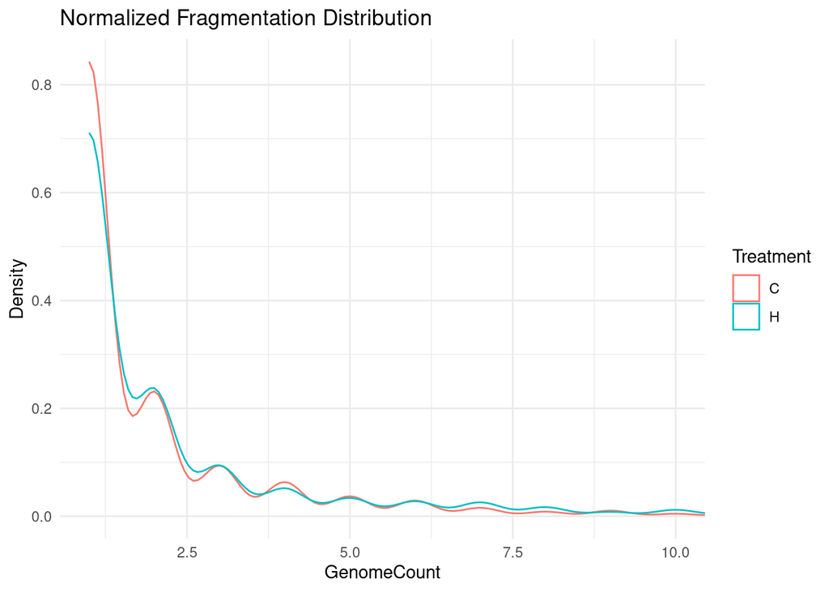

```r
ggplot(votu_taxonomy2,
       aes(x = GenomeCount, color = Treatment)) +
  geom_density(adjust = 2) +
  coord_cartesian(xlim = c(1, 10)) +
  theme_minimal() +
  labs(title = "Normalized Fragmentation Distribution",
       y = "Density")
```

# Bar graogh H v C per Phylum

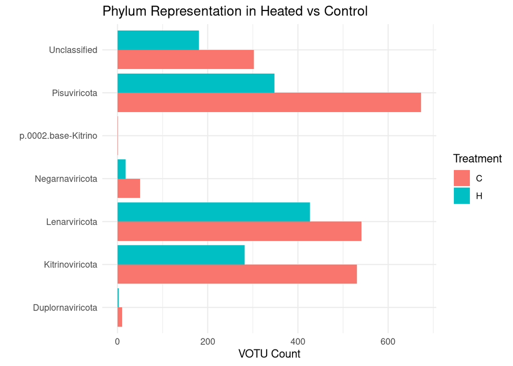

```r
ggplot2::ggplot(
  votu_taxonomy2 |>
    dplyr::count(Treatment, Phylum),
  ggplot2::aes(x = Phylum, y = n, fill = Treatment)
) +
  ggplot2::geom_col(position = "dodge") +
  ggplot2::coord_flip() +
  ggplot2::theme_minimal() +
  ggplot2::labs(
    title = "Phylum Representation in Heated vs Control",
    y = "VOTU Count",
    x = ""
  )
```

# Genome bin count v proportion of VOTUs

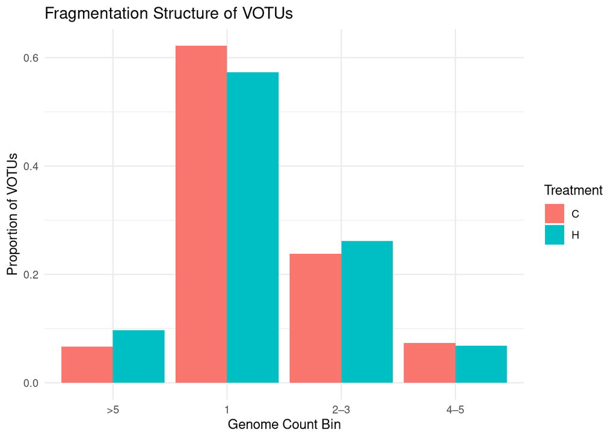

```r
ggplot(inflation_bins, aes(x = GC_bin, y = prop, fill = Treatment)) +
  geom_col(position = "dodge") +
  theme_minimal() +
  labs(
    title = "Fragmentation Structure of VOTUs",
    x = "Genome Count Bin",
    y = "Proportion of VOTUs"
  )
```

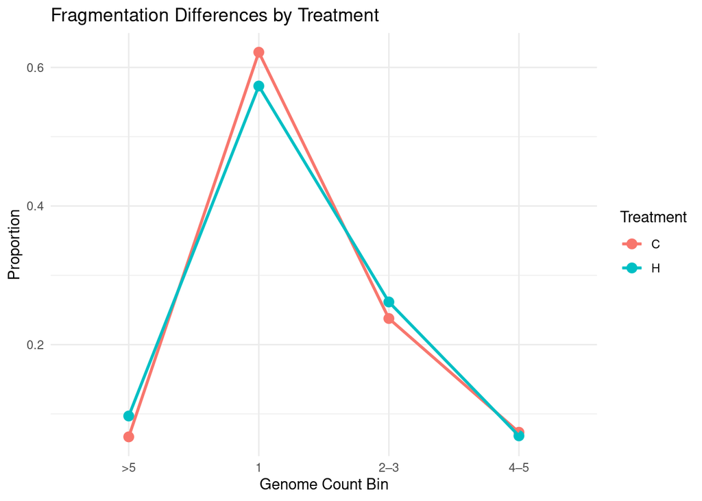

```r
bin_summary <- inflation_bins |>
  group_by(Treatment, GC_bin) |>
  summarize(
    prop = mean(prop),
    se = sd(prop),
    .groups="drop"
  )

ggplot(bin_summary,
       aes(GC_bin, prop, color = Treatment, group = Treatment)) +
  geom_point(size = 3) +
  geom_line(linewidth = 1) +
  geom_errorbar(aes(ymin = prop - se, ymax = prop + se), width = 0.1) +
  theme_minimal() +
  labs(
    title = "Fragmentation Differences by Treatment",
    x = "Genome Count Bin",
    y = "Proportion"
  )
```

# Effect of fragmentatipn shift (Cliff delta)

```r
library(effsize)
cliff.delta(
  votu_taxonomy2$GenomeCount[votu_taxonomy2$Treatment=="H"],
  votu_taxonomy2$GenomeCount[votu_taxonomy2$Treatment=="C"]
)
```

```
Cliff's Delta

delta estimate: 0.05427126 (negligible)
95 percent confidence interval:
     lower      upper
0.01844659 0.08995675
```

```r
frag_by_phylum <- votu_taxonomy2 |>
  group_by(Phylum, Treatment) |>
  summarize(
    median_gc = median(GenomeCount),
    mean_gc = mean(GenomeCount),
    prop_high = mean(GenomeCount > 3),
    n = n(),
    .groups="drop"
  )

frag_by_phylum
```

```
# A tibble: 13 × 6
   Phylum              Treatment median_gc mean_gc prop_high     n
   <chr>               <chr>         <dbl>   <dbl>     <dbl> <int>
 1 Duplornaviricota    C                 1    1.2     0         10
 2 Duplornaviricota    H                 1    3.33    0.333      3
 3 Kitrinoviricota     C                 1    2.19    0.162    531
 4 Kitrinoviricota     H                 1    2.74    0.202    282
 5 Lenarviricota       C                 1    1.78    0.104    541
 6 Lenarviricota       H                 1    1.96    0.122    427
 7 Negarnaviricota     C                 1    1.38    0.04      50
 8 Negarnaviricota     H                 1    2.06    0.167     18
 9 Pisuviricota        C                 1    2.74    0.211    673
10 Pisuviricota        H                 2    3.05    0.239    348
11 Unclassified        C                 1    1.27    0.0298   302
12 Unclassified        H                 1    1.69    0.0667   180
13 p.0002.base-Kitrino C                 9    9       1          1
```

# ============================================================

# METAGENOME-LEVEL VOTU RICHNESS AND T-TEST

# ============================================================

```r
frag_changes <- frag_by_phylum |>
  select(Phylum, Treatment, mean_gc, prop_high) |>
  pivot_wider(names_from = Treatment, values_from = c(mean_gc, prop_high))

frag_changes
```

```
# A tibble: 7 × 5
  Phylum              mean_gc_C mean_gc_H prop_high_C prop_high_H
  <chr>                   <dbl>     <dbl>       <dbl>       <dbl>
1 Duplornaviricota         1.2       3.33      0           0.333
2 Kitrinoviricota          2.19      2.74      0.162       0.202
3 Lenarviricota            1.78      1.96      0.104       0.122
4 Negarnaviricota          1.38      2.06      0.04        0.167
5 Pisuviricota             2.74      3.05      0.211       0.239
6 Unclassified             1.27      1.69      0.0298      0.0667
7 p.0002.base-Kitrino      9        NA         1          NA
```

```r
# ── 1. Aggregate to biological-sample level ─────────────────
# ND = one contig/detection, so we roll up to the true
# metagenome unit: Site × Subplot × Layer (Treatment follows)

votu_richness_meta <- votu_rdrp |>
  dplyr::group_by(Site, Subplot, Layer, Treatment) |>
  dplyr::summarize(
    VOTUrichness   = dplyr::n_distinct(VOTU),
    GenomeRichness = dplyr::n_distinct(Contig),
    .groups        = "drop"
  )

# Quick per-treatment summary
votu_richness_meta |>
  dplyr::group_by(Treatment) |>
  dplyr::summarize(
    n           = dplyr::n(),
    mean_VOTU   = mean(VOTUrichness),
    sd_VOTU     = sd(VOTUrichness),
    median_VOTU = median(VOTUrichness)
  )
```

```
# A tibble: 2 × 5
  Treatment     n mean_VOTU sd_VOTU median_VOTU
  <chr>     <int>     <dbl>   <dbl>       <dbl>
1 C            14      267    107.          255
2 H            14      178.    51.1         179
```

```r
# ── 2. Normality check before choosing test ─────────────────
shapiro_C <- shapiro.test(
  votu_richness_meta$VOTUrichness[votu_richness_meta$Treatment == "C"]
)
shapiro_H <- shapiro.test(
  votu_richness_meta$VOTUrichness[votu_richness_meta$Treatment == "H"]
)

cat("Shapiro-Wilk  Control : W =", round(shapiro_C$statistic, 4),
    "  p =", round(shapiro_C$p.value, 4), "\n")
```

```
Shapiro-Wilk  Control : W = 0.9207   p = 0.2247
```

```r
cat("Shapiro-Wilk  Heated  : W =", round(shapiro_H$statistic, 4),
    "  p =", round(shapiro_H$p.value, 4), "\n")
```

```
Shapiro-Wilk  Heated  : W = 0.937   p = 0.381
```

```r
# p < 0.05 in either → favour the Wilcoxon fallback below

# ── 3. Welch two-sample t-test (primary) ────────────────────
# var.equal = FALSE (Welch correction) is safest for unequal n
ttest_votu <- t.test(
  VOTUrichness ~ Treatment,
  data      = votu_richness_meta,
  var.equal = FALSE
)
ttest_votu                   # full output
```

```
    Welch Two Sample t-test

data:  VOTUrichness by Treatment
t = 2.8226, df = 18.634, p-value = 0.01101
alternative hypothesis: true difference in means between group C and group H is not equal to 0
95 percent confidence interval:
  23.02791 155.82923
sample estimates:
mean in group C mean in group H
       267.0000        177.5714
```

```r
broom::tidy(ttest_votu)      # tidy one-row tibble (great for reporting)
```

```
# A tibble: 1 × 10
  estimate estimate1 estimate2 statistic p.value parameter conf.low conf.high
     <dbl>     <dbl>     <dbl>     <dbl>   <dbl>     <dbl>    <dbl>     <dbl>
1     89.4       267      178.      2.82  0.0110      18.6     23.0      156.
# ℹ 2 more variables: method <chr>, alternative <chr>
```

```r
# ── 4. Non-parametric fallback ───────────────────────────────
# Use this if Shapiro-Wilk flags non-normality in either group
wilcox_votu <- wilcox.test(
  VOTUrichness ~ Treatment,
  data = votu_richness_meta
)
wilcox_votu
```

```
    Wilcoxon rank sum test with continuity correction

data:  VOTUrichness by Treatment
W = 144, p-value = 0.03654
alternative hypothesis: true location shift is not equal to 0
```

# ============================================================

# BOXPLOT: VOTU RICHNESS PER METAGENOME WITH SIGNIFICANCE

# ============================================================

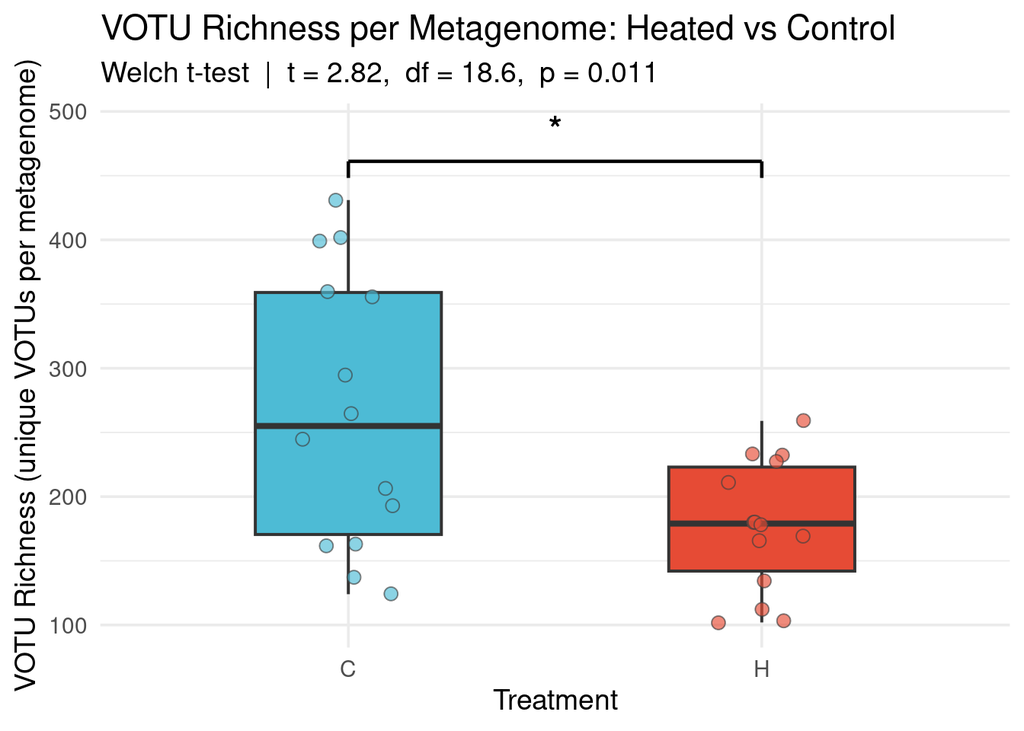

```r
library(ggplot2)

# ── Build bracket annotation values ─────────────────────────
p_val   <- ttest_votu$p.value

p_label <- dplyr::case_when(
  p_val < 0.001 ~ "***",
  p_val < 0.01  ~ "**",
  p_val < 0.05  ~ "*",
  TRUE          ~ paste0("ns  (p = ", round(p_val, 3), ")")
)

y_max   <- max(votu_richness_meta$VOTUrichness, na.rm = TRUE)
y_bar   <- y_max * 1.07    # horizontal bracket line
y_ticks <- y_max * 1.04    # short vertical ticks at each end
y_text  <- y_max * 1.13    # label sits above the bracket

# ── Plot ─────────────────────────────────────────────────────
ggplot2::ggplot(
  votu_richness_meta,
  ggplot2::aes(x = Treatment, y = VOTUrichness, fill = Treatment)
) +
  # ── boxes ──
  ggplot2::geom_boxplot(
    outlier.alpha = 0.4,
    width         = 0.45,
    linewidth     = 0.7
  ) +
  # ── individual sample points ──
  ggplot2::geom_jitter(
    ggplot2::aes(fill = Treatment),
    width   = 0.12,
    alpha   = 0.65,
    size    = 2.8,
    shape   = 21,
    colour  = "grey25"
  ) +
  # ── colours ──
  ggplot2::scale_fill_manual(
    values = c("C" = "#4DBBD5", "H" = "#E64B35"),
    labels = c("C" = "Control", "H" = "Heated")
  ) +
  # ── significance bracket: horizontal bar ──
  ggplot2::annotate(
    "segment",
    x = 1, xend = 2, y = y_bar, yend = y_bar,
    linewidth = 0.8

  ) +
  # ── left tick ──
  ggplot2::annotate(
    "segment",
    x = 1, xend = 1, y = y_bar, yend = y_ticks,
    linewidth = 0.8
  ) +
  # ── right tick ──
  ggplot2::annotate(
    "segment",
    x = 2, xend = 2, y = y_bar, yend = y_ticks,
    linewidth = 0.8
  ) +
  # ── p-value / star label ──
  ggplot2::annotate(
    "text",
    x        = 1.5,
    y        = y_text,
    label    = p_label,
    size     = 6,
    fontface = "bold"
  ) +
  # ── theme and labels ──
  ggplot2::theme_minimal(base_size = 14) +
  ggplot2::labs(
    title    = "VOTU Richness per Metagenome: Heated vs Control",
    subtitle = paste0(
      "Welch t-test  |  t = ", round(ttest_votu$statistic, 2),
      ",  df = ",  round(ttest_votu$parameter, 1),
      ",  p = ",  signif(ttest_votu$p.value, 3)
    ),
    x    = "Treatment",
    y    = "VOTU Richness (unique VOTUs per metagenome)",
    fill = "Treatment"
  ) +
  ggplot2::theme(legend.position = "none")
```

# Beta diversity matrix - difference between each different metagenome

```r
  # ============================================================
# STEP 1: BUILD METAGENOME × VOTU ABUNDANCE MATRIX
# ============================================================

# 1a. Assign a unique ID to each biological metagenome
#     (Site + Subplot + Layer + Treatment = one soil core)
votu_rdrp_meta <- votu_rdrp |>
  dplyr::filter(!is.na(VOTU)) |>                        # drop missing VOTUs
  dplyr::mutate(
    SampleID = paste(Site, Subplot, Layer, Treatment, sep = "_")
  )

# 1b. Count distinct contigs per VOTU per metagenome (abundance)
votu_abund <- votu_rdrp_meta |>
  dplyr::group_by(SampleID, VOTU) |>
  dplyr::summarize(n_contigs = dplyr::n_distinct(Contig), .groups = "drop")

# 1c. Pivot to wide: rows = metagenomes, columns = VOTUs
votu_wide <- votu_abund |>
  tidyr::pivot_wider(
    names_from  = VOTU,
    values_from = n_contigs,
    values_fill = 0
  )

# 1d. Pull sample metadata (one row per metagenome)
sample_meta <- votu_rdrp_meta |>
  dplyr::distinct(SampleID, Treatment, Site, Subplot, Layer)

# 1e. Numeric matrix with sample IDs as rownames
mat <- votu_wide |>
  tibble::column_to_rownames("SampleID") |>
  as.matrix()

# 1f. Align metadata rows to matrix row order — critical for vegan
meta_ordered <- sample_meta[match(rownames(mat), sample_meta$SampleID), ]

cat("Matrix:", nrow(mat), "metagenomes ×", ncol(mat), "VOTUs\n")
```

```
Matrix: 28 metagenomes × 2995 VOTUs
```

# ============================================================

# STEP 2: DISSIMILARITY + STATISTICAL TESTS

# ============================================================

```r
library(vegan)

# 2a. Bray-Curtis dissimilarity between every pair of metagenomes
#     Value of 0 = identical  |  Value of 1 = completely different
bc_dist <- vegan::vegdist(mat, method = "bray")

# ── PERMANOVA ────────────────────────────────────────────────
# The proper multivariate test replacing a t-test here
# Question: does Treatment explain differences between metagenomes?
set.seed(42)
permanova_res <- vegan::adonis2(
  bc_dist ~ Treatment,
  data         = meta_ordered,
  permutations = 999
)
print(permanova_res)
```

```
Permutation test for adonis under reduced model
Terms added sequentially (first to last)
Permutation: free
Number of permutations: 999

vegan::adonis2(formula = bc_dist ~ Treatment, data = meta_ordered, permutations = 999)
          Df SumOfSqs      R2      F Pr(>F)
Treatment  1   1.3725 0.13183 3.9479  0.001 ***
Residual  26   9.0386 0.86817
Total     27  10.4111 1.00000
---
Signif. codes:  0 '***' 0.001 '**' 0.01 '*' 0.05 '.' 0.1 ' ' 1
```

```r
# R²  = proportion of variance explained by treatment
# p   < 0.05 = metagenomes differ significantly by treatment

# ── Betadisper ───────────────────────────────────────────────
# Tests whether within-group SPREAD differs between treatments
# Run this before trusting PERMANOVA — if significant, PERMANOVA
# may be detecting spread differences, not true community shifts
betadisp_res  <- vegan::betadisper(bc_dist, meta_ordered$Treatment)
betadisp_test <- permutest(betadisp_res, permutations = 999)
print(betadisp_test)
```

```
Permutation test for homogeneity of multivariate dispersions
Permutation: free
Number of permutations: 999

Response: Distances
          Df    Sum Sq   Mean Sq      F N.Perm Pr(>F)
Groups     1 0.0050669 0.0050669 8.2821    999  0.014 *
Residuals 26 0.0159065 0.0006118
---
Signif. codes:  0 '***' 0.001 '**' 0.01 '*' 0.05 '.' 0.1 ' ' 1
```

```r
# Non-significant = equal spread = PERMANOVA result is reliable
```

# ============================================================

# STEP 3: NMDS PLOT (each point = one metagenome)

# ============================================================

```r
set.seed(42)
nmds <- vegan::metaMDS(mat, distance = "bray", k = 2, trymax = 100)
```

```
*** Best solution repeated 1 times
```

```r
cat("NMDS stress =", round(nmds$stress, 3), "\n")
```

```
NMDS stress = 0.184
```

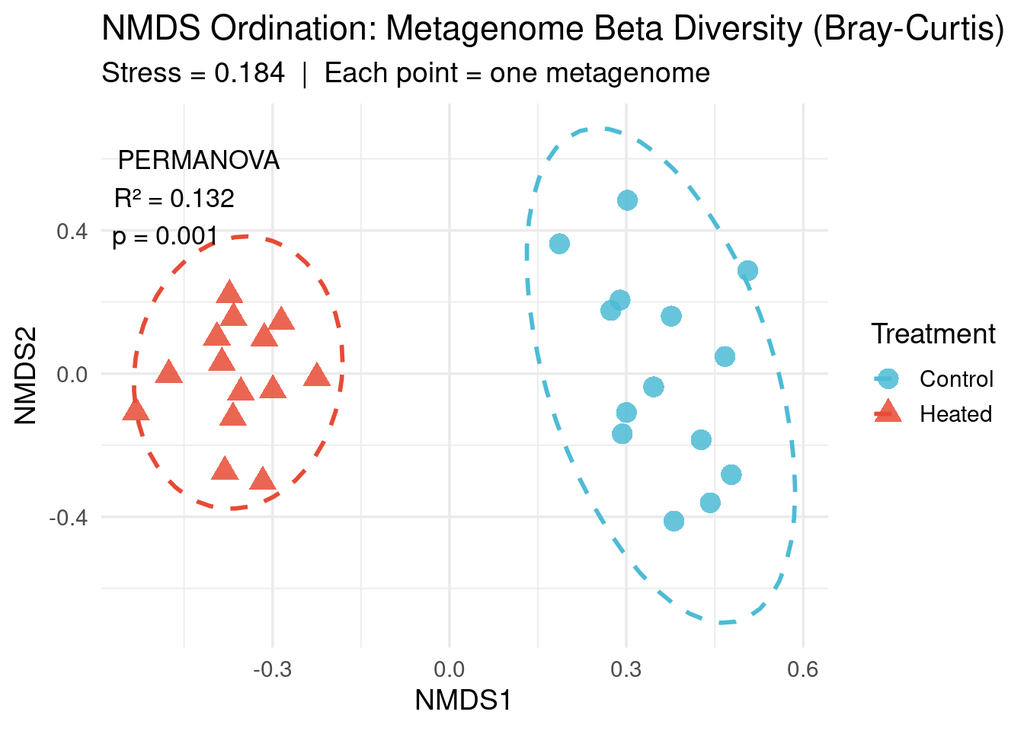

```r
# < 0.10 = great  |  < 0.20 = acceptable  |  > 0.20 = unreliable

# Build scores dataframe
nmds_df <- as.data.frame(vegan::scores(nmds, display = "sites")) |>
  tibble::rownames_to_column("SampleID") |>
  dplyr::left_join(meta_ordered, by = "SampleID")

ggplot2::ggplot(
  nmds_df,
  ggplot2::aes(NMDS1, NMDS2, color = Treatment, shape = Treatment)
) +
  ggplot2::geom_point(size = 4.5, alpha = 0.85) +
  ggplot2::stat_ellipse(                          # 95% confidence ellipse per group
    level     = 0.95,
    linewidth = 1,
    linetype  = "dashed"
  ) +
  ggplot2::scale_color_manual(
    values = c("C" = "#4DBBD5", "H" = "#E64B35"),
    labels = c("C" = "Control", "H" = "Heated")
  ) +
  ggplot2::scale_shape_manual(
    values = c("C" = 16, "H" = 17),
    labels = c("C" = "Control", "H" = "Heated")
  ) +
  ggplot2::annotate(
    "text", x = -Inf, y = Inf,
    label = paste0(
      "PERMANOVA\nR² = ", round(permanova_res$R2[1], 3),
      "\np = ",           permanova_res$`Pr(>F)`[1]
    ),
    hjust = -0.1, vjust = 1.5, size = 4.5
  ) +
  ggplot2::theme_minimal(base_size = 14) +
  ggplot2::labs(
    title    = "NMDS Ordination: Metagenome Beta Diversity (Bray-Curtis)",
    subtitle = paste0(
      "Stress = ", round(nmds$stress, 3),
      "  |  Each point = one metagenome"
    ),
    color = "Treatment",
    shape = "Treatment"
  )
```

# ============================================================

# STEP 4: PAIRWISE DISTANCE BOXPLOT WITH SIGNIFICANCE

# ============================================================

```r
# 4a. Expand distance matrix to long format (upper triangle only)
dist_mat <- as.matrix(bc_dist)

pairs_df <- expand.grid(
  i = rownames(dist_mat),
  j = rownames(dist_mat),
  stringsAsFactors = FALSE
) |>
  dplyr::filter(i < j) |>                              # avoid duplicates
  dplyr::mutate(
    Distance = dist_mat[cbind(i, j)],
    Treat_i  = meta_ordered$Treatment[match(i, meta_ordered$SampleID)],
    Treat_j  = meta_ordered$Treatment[match(j, meta_ordered$SampleID)],
    Comparison = factor(
      dplyr::case_when(
        Treat_i == "C" & Treat_j == "C" ~ "Within Control",
        Treat_i == "H" & Treat_j == "H" ~ "Within Heated",
        TRUE                             ~ "Between C & H"
      ),
      levels = c("Within Control", "Within Heated", "Between C & H")
    )
  )

# 4b. Welch t-tests between each pair of comparison groups
#     (direct vector approach avoids factor-level issues)
tt_WC_WH <- t.test(
  pairs_df$Distance[pairs_df$Comparison == "Within Control"],
  pairs_df$Distance[pairs_df$Comparison == "Within Heated"]
)
tt_WH_B <- t.test(
  pairs_df$Distance[pairs_df$Comparison == "Within Heated"],
  pairs_df$Distance[pairs_df$Comparison == "Between C & H"]
)
tt_WC_B <- t.test(
  pairs_df$Distance[pairs_df$Comparison == "Within Control"],
  pairs_df$Distance[pairs_df$Comparison == "Between C & H"]
)

# Star labels
p_star <- function(p) {
  if      (p < 0.001) "***"
  else if (p < 0.01)  "**"
  else if (p < 0.05)  "*"
  else                 "ns"
}

cat("Within Control vs Within Heated :",
    "t =", round(tt_WC_WH$statistic, 2),
    " p =", round(tt_WC_WH$p.value, 4),
    p_star(tt_WC_WH$p.value), "\n")
```

```
Within Control vs Within Heated : t = 4.14  p = 1e-04 ***
```

```r
cat("Within Heated  vs Between C & H :",
    "t =", round(tt_WH_B$statistic, 2),
    " p =", round(tt_WH_B$p.value, 4),
    p_star(tt_WH_B$p.value), "\n")
```

```
Within Heated  vs Between C & H : t = -14.23  p = 0 ***
```

```r
cat("Within Control vs Between C & H :",
    "t =", round(tt_WC_B$statistic, 2),
    " p =", round(tt_WC_B$p.value, 4),
    p_star(tt_WC_B$p.value), "\n")
```

```
Within Control vs Between C & H : t = -10.26  p = 0 ***
```

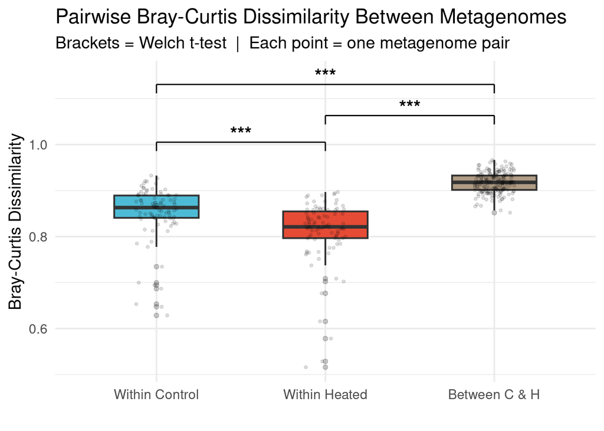

```r
# 4c. Boxplot with three significance brackets
y_max <- max(pairs_df$Distance)

ggplot2::ggplot(
  pairs_df,
  ggplot2::aes(x = Comparison, y = Distance, fill = Comparison)
) +
  ggplot2::geom_boxplot(
    outlier.alpha = 0.25,
    width         = 0.5,
    linewidth     = 0.7
  ) +
  ggplot2::geom_jitter(width = 0.12, alpha = 0.12, size = 0.9) +
  ggplot2::scale_fill_manual(values = c(
    "Within Control" = "#4DBBD5",
    "Within Heated"  = "#E64B35",
    "Between C & H"  = "#B09C85"
  )) +

  # ── bracket 1: Within Control vs Within Heated ──────────
  ggplot2::annotate("segment",
    x = 1, xend = 2, y = y_max * 1.04, yend = y_max * 1.04) +
  ggplot2::annotate("segment",
    x = 1, xend = 1, y = y_max * 1.04, yend = y_max * 1.02) +
  ggplot2::annotate("segment",
    x = 2, xend = 2, y = y_max * 1.04, yend = y_max * 1.02) +
  ggplot2::annotate("text",
    x = 1.5, y = y_max * 1.06,
    label = p_star(tt_WC_WH$p.value), size = 5.5, fontface = "bold") +

  # ── bracket 2: Within Heated vs Between ─────────────────
  ggplot2::annotate("segment",
    x = 2, xend = 3, y = y_max * 1.10, yend = y_max * 1.10) +
  ggplot2::annotate("segment",
    x = 2, xend = 2, y = y_max * 1.10, yend = y_max * 1.08) +
  ggplot2::annotate("segment",
    x = 3, xend = 3, y = y_max * 1.10, yend = y_max * 1.08) +
  ggplot2::annotate("text",
    x = 2.5, y = y_max * 1.12,
    label = p_star(tt_WH_B$p.value), size = 5.5, fontface = "bold") +

  # ── bracket 3: Within Control vs Between ────────────────
  ggplot2::annotate("segment",
    x = 1, xend = 3, y = y_max * 1.17, yend = y_max * 1.17) +
  ggplot2::annotate("segment",
    x = 1, xend = 1, y = y_max * 1.17, yend = y_max * 1.15) +
  ggplot2::annotate("segment",
    x = 3, xend = 3, y = y_max * 1.17, yend = y_max * 1.15) +
  ggplot2::annotate("text",
    x = 2, y = y_max * 1.19,
    label = p_star(tt_WC_B$p.value), size = 5.5, fontface = "bold") +

  ggplot2::theme_minimal(base_size = 14) +
  ggplot2::labs(
    title    = "Pairwise Bray-Curtis Dissimilarity Between Metagenomes",
    subtitle = "Brackets = Welch t-test  |  Each point = one metagenome pair",
    x        = "",
    y        = "Bray-Curtis Dissimilarity",
    fill     = ""
  ) +
  ggplot2::theme(legend.position = "none")
```